# Individual Code

Ying Chen

2026-04-21

```r
library(jsonlite)
fromJSON("data_raw/archive/stations.json")
```

[output not shown]

[output cut: 35953 more lines]

```r
list.files("data_raw", recursive = TRUE)
```

```
##  [1] "2011 Population Census Abstract/pc11_pca_clean_con07.csv"
##  [2] "2011 Population Census Abstract/pc11_pca_clean_con08.csv"
##  [3] "2011 Population Census Abstract/pc11_pca_clean_pc11dist.csv"
##  [4] "2011 Population Census Abstract/pc11_pca_clean_pc11subdist.csv"
##  [5] "2011 Population Census Abstract/pc11_pca_clean_shrid.csv"
##  [6] "2011 Population Census Abstract/population_census.bib"
##  [7] "2011 Population Census Abstract/README.md"
##  [8] "archive/schedules.json"
##  [9] "archive/stations.json"
## [10] "archive/trains.json"
## [11] "archivegdp/Economy_Productivity_SD_India.csv"
## [12] "archivegdp/GDP_Sector_Income_2019_2023_30Cities.csv"
## [13] "SECC Rural/README.md"
## [14] "SECC Rural/secc.bib"
## [15] "SECC Rural/secc_rural_con07.csv"
```

[output cut: 18 more lines]

```r
set.seed(6414)
```

#load rail road file

```r
stations_raw <- fromJSON("data_raw/archive/stations.json")

stations_features <- stations_raw$features
stations_df <- stations_features$properties

head(stations_df)
```

```
##           state    code     name zone                      address
## 1     Rajasthan    BDHL   Badhal  NWR Kishangarh Renwal, Rajasthan
## 2          <NA> XX-BECE  XX-BECE <NA>                         <NA>
## 3          <NA> XX-BSPY  XX-BSPY <NA>                         <NA>
## 4          <NA> YY-BPLC  YY-BPLC <NA>                         <NA>
## 5 Uttar Pradesh     KHH   KICHHA  NER        Kichha, Uttar Pradesh
## 6     Rajasthan    SRKN Sherekan  NWR            MDR 89, Rajasthan
```

```r
dim(stations_df)
```

```
## [1] 8990    5
```

```r
colnames(stations_df)
```

```
## [1] "state"   "code"    "name"    "zone"    "address"
```

# Clean the station data

```r
# Remove rows with missing state
stations_df <- stations_df[!is.na(stations_df$state), ]

# Remove fake stations (codes starting with "XX" or "YY")
stations_df <- stations_df[!grepl("^XX|^YY", stations_df$code), ]

# Check results
dim(stations_df)
```

```
## [1] 4458    5
```

```r
head(stations_df)
```

```
##           state code      name zone                      address
## 1     Rajasthan BDHL    Badhal  NWR Kishangarh Renwal, Rajasthan
## 5 Uttar Pradesh  KHH    KICHHA  NER        Kichha, Uttar Pradesh
## 6     Rajasthan SRKN  Sherekan  NWR            MDR 89, Rajasthan
## 7     Rajasthan BKKA  Bhukarka  NWR          Bhukarka, Rajasthan
## 8     Rajasthan  NHR     Nohar  NWR  State Highway 36, Rajasthan
## 9    Tamil Nadu PRGD Perungudi   SR          Chennai, Tamil Nadu
```

#Create your RAS variable

```r
# Count stations per state
station_count_state <- aggregate(code ~ state, data = stations_df, FUN = length)
colnames(station_count_state)[2] <- "station_count"

# Create log-based RAS proxy
station_count_state$log_station <- log(station_count_state$station_count)

# Check
summary(station_count_state$log_station)
```

```
##    Min. 1st Qu.  Median    Mean 3rd Qu.    Max.
##   0.000   2.802   4.182   3.940   5.489   6.271
```

```r
head(station_count_state)
```

```
##            state station_count log_station
## 1                           61   4.1108739
## 2 Andhra Pradesh           204   5.3181200
## 3          Assam           194   5.2678582
## 4     Bangladesh             2   0.6931472
## 5          Bihar           210   5.3471075
## 6     Chandigarh             2   0.6931472
```

# Next, Bring in population and terrain.

Preliminary state-level rail accessibility model Limitation: this model aggregates station data to the state level. Our final analysis will use station-level RAS and district-level aggregation.

```r
# Load population
pop <- read.csv("data_raw/2011 Population Census Abstract/pc11_pca_clean_pc11dist.csv")

# Load TRI
tri <- read.csv("data_raw/Terrain Ruggedness Index (TRI)/tri_pc11dist.csv")

# Keep needed columns
pop_small <- pop[, c("pc11_state_id", "pc11_pca_tot_p")]
tri_small <- tri[, c("pc11_state_id", "tri_mean")]

# Aggregate to state level
pop_state <- aggregate(pc11_pca_tot_p ~ pc11_state_id, data = pop_small, sum)
tri_state <- aggregate(tri_mean ~ pc11_state_id, data = tri_small, mean)

# Create log population
pop_state$log_pop <- log(pop_state$pc11_pca_tot_p)

# Check
head(pop_state)
```

```
##   pc11_state_id pc11_pca_tot_p  log_pop
## 1             1       12541302 16.34454
## 2             2        6864602 15.74189
## 3             3       27743338 17.13851
## 4             4        1055450 13.86948
## 5             5       10086292 16.12669
## 6             6       25351462 17.04835
```

```r
head(tri_state)
```

```
##   pc11_state_id  tri_mean
## 1             1 28.505193
## 2             2 33.291311
## 3             3  4.349178
## 4             4  4.927455
## 5             5 33.004968
## 6             6  4.701588
```

#create state lookup table

```r
state_lookup <- data.frame(
  pc11_state_id = 1:35,
  state = c(
    "", "Andhra Pradesh", "Assam", "Bihar", "Chandigarh",
    "Chhattisgarh", "Delhi NCT", "Goa", "Gujarat", "Haryana",
    "Himachal Pradesh", "Jammu and Kashmir", "Jharkhand", "Karnataka",
    "Kerala", "Madhya Pradesh", "Maharashtra", "Mizoram", "Nagaland",
    "Odisha", "Orissa", "Puducherry", "Punjab", "Rajasthan",
    "Tamil Nadu", "Tripura", "Uttar Pradesh", "Uttarakhand",
    "West Bengal", NA, NA, NA, NA, NA, NA
  )
)

head(state_lookup, 10)
```

```
##    pc11_state_id          state
## 1              1
## 2              2 Andhra Pradesh
## 3              3          Assam
## 4              4          Bihar
## 5              5     Chandigarh
## 6              6   Chhattisgarh
## 7              7      Delhi NCT
## 8              8            Goa
## 9              9        Gujarat
## 10            10        Haryana
```

```r
dim(state_lookup)
```

```
## [1] 35  2
```

#merge population + terrain + state names

```r
# Merge population and terrain by state ID
state_predictors <- merge(pop_state, tri_state, by = "pc11_state_id")

# Add state names
state_predictors <- merge(state_predictors, state_lookup, by = "pc11_state_id")

# Check
head(state_predictors)
```

```
##   pc11_state_id pc11_pca_tot_p  log_pop  tri_mean          state
## 1             1       12541302 16.34454 28.505193
## 2             2        6864602 15.74189 33.291311 Andhra Pradesh
## 3             3       27743338 17.13851  4.349178          Assam
## 4             4        1055450 13.86948  4.927455          Bihar
## 5             5       10086292 16.12669 33.004968     Chandigarh
## 6             6       25351462 17.04835  4.701588   Chhattisgarh
```

```r
dim(state_predictors)
```

```
## [1] 35  5
```

#merge railway response with predictors

```r
# Remove invalid/non-India rows before merge
station_count_state <- station_count_state[!is.na(station_count_state$state), ]
station_count_state <- station_count_state[station_count_state$state != "", ]
station_count_state <- station_count_state[station_count_state$state != "Bangladesh", ]

# Merge RAS response with state predictors
model_data <- merge(station_count_state, state_predictors, by = "state")

# Check final model data
head(model_data)
```

```
##            state station_count log_station pc11_state_id pc11_pca_tot_p
## 1 Andhra Pradesh           204   5.3181200             2        6864602
## 2          Assam           194   5.2678582             3       27743338
## 3          Bihar           210   5.3471075             4        1055450
## 4     Chandigarh             2   0.6931472             5       10086292
## 5   Chhattisgarh            57   4.0430513             6       25351462
## 6      Delhi NCT            28   3.3322045             7       16787941
##    log_pop  tri_mean
## 1 15.74189 33.291311
## 2 17.13851  4.349178
## 3 13.86948  4.927455
## 4 16.12669 33.004968
## 5 17.04835  4.701588
## 6 16.63617  5.216129
```

```r
dim(model_data)
```

```
## [1] 28  7
```

```r
colnames(model_data)
```

```
## [1] "state"          "station_count"  "log_station"    "pc11_state_id"
## [5] "pc11_pca_tot_p" "log_pop"        "tri_mean"
```

```r
summary(model_data)
```

```
##     state           station_count    log_station    pc11_state_id
##  Length:28          Min.   :  1.0   Min.   :0.000   Min.   : 2.00
##  Class :character   1st Qu.: 17.5   1st Qu.:2.861   1st Qu.: 8.75
##  Mode  :character   Median : 76.5   Median :4.328   Median :15.50
##                     Mean   :157.0   Mean   :4.050   Mean   :15.50
##                     3rd Qu.:265.0   3rd Qu.:5.577   3rd Qu.:22.25
##                     Max.   :529.0   Max.   :6.271   Max.   :29.00
##  pc11_pca_tot_p         log_pop         tri_mean
##  Min.   :   243247   Min.   :12.40   Min.   : 3.704
##  1st Qu.:  2636471   1st Qu.:14.77   1st Qu.: 5.084
##  Median : 25448330   Median :17.05   Median : 6.728
##  Mean   : 38910562   Mean   :16.30   Mean   :13.381
##  3rd Qu.: 62958582   3rd Qu.:17.96   3rd Qu.:19.769
##  Max.   :199812341   Max.   :19.11   Max.   :43.369
```

# Now, my model_data is ready.

```r
# Fit baseline rail accessibility model
rail_model <- lm(
  log_station ~ log_pop + tri_mean,
  data = model_data
)

summary(rail_model)
```

```
##
## Call:
## lm(formula = log_station ~ log_pop + tri_mean, data = model_data)
##
## Residuals:
##     Min      1Q  Median      3Q     Max
## -4.0786 -0.9676  0.4044  1.5323  2.3676
##
## Coefficients:
##             Estimate Std. Error t value Pr(>|t|)
## (Intercept)  6.66625    3.99058   1.670    0.107
## log_pop     -0.14047    0.22647  -0.620    0.541
## tri_mean    -0.02443    0.03561  -0.686    0.499
##
## Residual standard error: 1.93 on 25 degrees of freedom
## Multiple R-squared:  0.0217, Adjusted R-squared:  -0.05657
## F-statistic: 0.2772 on 2 and 25 DF,  p-value: 0.7602
```

# summary from above:

The regression results do not show statistically significant relationships between population size, terrain ruggedness, and railway station density at the state level. This suggests that variation in railway access is not well explained by these aggregate factors alone.

#one clean figure for report

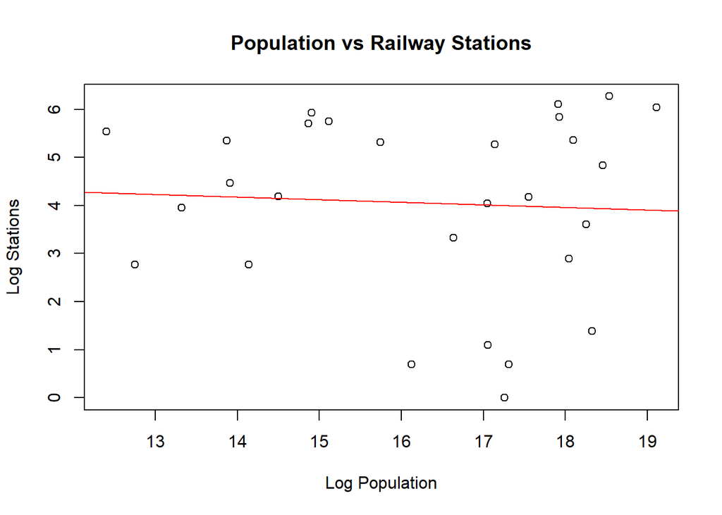

```r
simple_model <- lm(log_station ~ log_pop, data = model_data)

plot(model_data$log_pop, model_data$log_station,
     xlab = "Log Population",
     ylab = "Log Stations",
     main = "Population vs Railway Stations")

abline(simple_model, col = "red")
```

#The scatter plot shows a weak negative relationship between population size and the number of railway stations. While the fitted line slopes downward, indicating that more populous states tend to have relatively fewer stations, the relationship is highly dispersed, suggesting substantial unexplained variation.

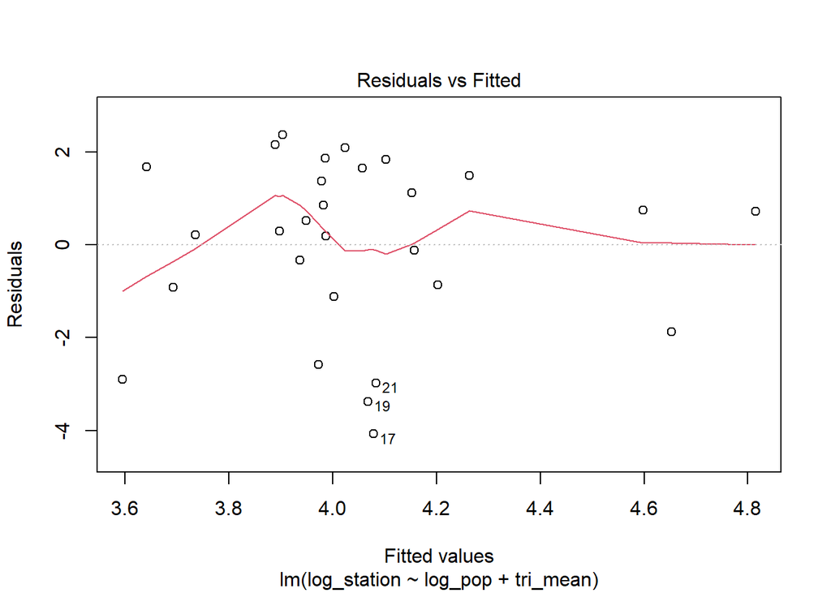

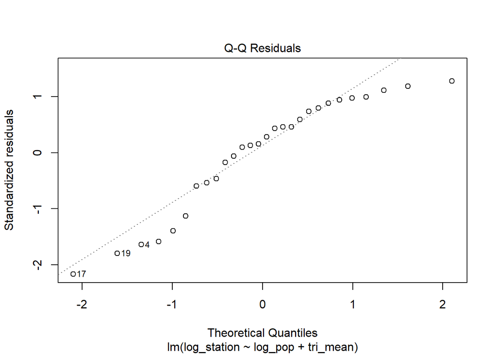

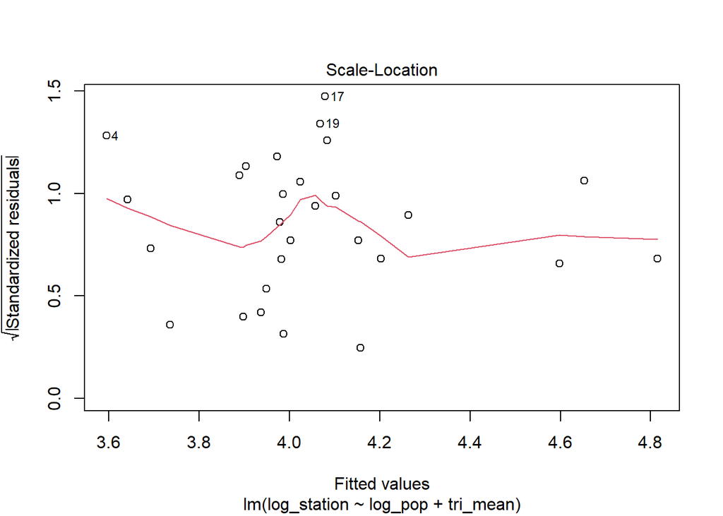

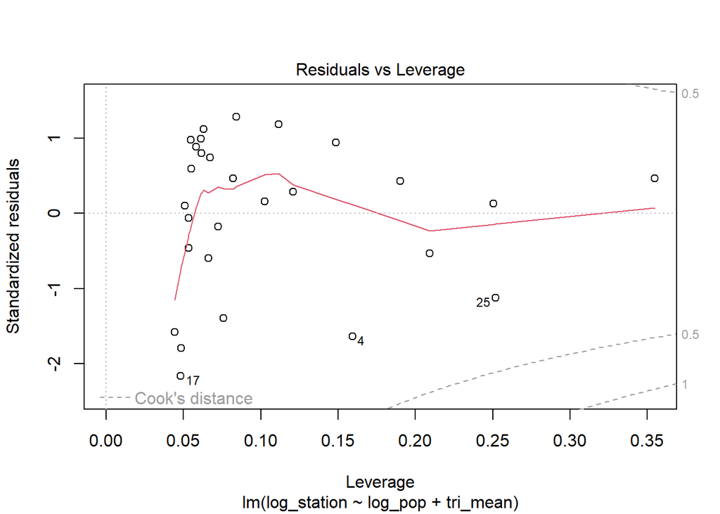

```r
plot(rail_model)
```

#summary: Linearity (Residuals vs Fitted): does not exhibit a strong systematic pattern, suggesting that the linearity assumption is reasonably satisfied, although slight curvature indicates potential mild nonlinearity. Normality (Q-Q Plot): indicates approximate normality of residuals, though deviations at the tails suggest departures from normality for extreme observations. Homoskedasticity (Scale-Location): the plot suggests that residual variance is relatively stable across fitted values, with only minor heteroskedasticity present. Influence / Outliers (Leverage + Cook’s Distance): identifies a small number of moderately influential observations; however, no points exceed conventional Cook’s distance thresholds, indicating that no single observation unduly influences the model estimates.

Overall: while minor deviations from ideal assumptions are present, the diagnostic results do not indicate severe violations, and the model is considered adequate for exploratory analysis.

#Summary: The model exhibits very low explanatory power (R² ≈ 0.02), and the overall F-test fails to reject the null hypothesis that all coefficients are jointly zero (p = 0.76). Neither population nor terrain ruggedness is statistically significant. This suggests that the current specification is insufficient to explain variation in railway station distribution. Despite the low predictive power, the residuals still provide a preliminary indication of mismatch between observed and expected rail supply. However, given the poor model fit, these residuals should not be interpreted as reliable measures of rail adequacy. Future improvements would include incorporating additional predictors such as GDP per capita, population density, and connectivity measures, as well as exploring alternative model forms. These variables are expected to better capture structural demand for railway infrastructure.

```r
set.seed(6414)

# Split data into 80% training and 20% testing
train_index <- sample(seq_len(nrow(model_data)), size = 0.8 * nrow(model_data))

train_data <- model_data[train_index, ]
test_data  <- model_data[-train_index, ]

# Fit model on training data
train_model <- lm(log_station ~ log_pop + tri_mean, data = train_data)

# Predict on test data
test_pred <- predict(train_model, newdata = test_data)

# Evaluate performance
rmse <- sqrt(mean((test_data$log_station - test_pred)^2))
mae  <- mean(abs(test_data$log_station - test_pred))

rmse
```

```
## [1] 1.583264
```

```r
mae
```

```
## [1] 1.368661
```

#The out-of-sample performance indicates relatively high prediction error (RMSE ≈ 1.58, MAE ≈ 1.37), consistent with the low explanatory power observed in the regression model.

```r
train_index <- sample(seq_len(nrow(model_data)))
train_index <- train_index[1:floor(0.8 * nrow(model_data))]
```

```r
write.csv(model_data, "final_state_dataset.csv", row.names = FALSE)
```